# Tugas MPDW Praktikum 5 : Pemeriksaan kestasioneran data

Kali ini akan dilakukan pengecekan kestasioneran data baik itu secara rataan maupun ragam. Disini akan menekankan bagaimana kita dapat mengetahui suatu data stasioner atau tidaknya. Dilakukan pula partisi untuk mengecek kestasioneran sebagian data dari data yang dibawakan.

```r
#library yang digunakan
library(ggplot2)
library(tsibble)
library(tseries)
library(MASS)
```

## Kestasioneran Data Asli

Pada tahap ini data asli milik pribadi peneliti berupa data time series bulanan menganai kurs uang dalam usd akan diteliti kestasionerannya. Data sendiri ada di github pribadi peneliti.

```r
df<- rio::import("https://raw.githubusercontent.com/fax17/MPDW/main/data/data.csv")
df
```

```
##     Periode     bulan   USD
## 1         1   Januari  9450
## 2         2  Februari  9835
## 3         3     Maret 10400
## 4         4     April 11675
## 5         5       Mei 11058
## 6         6      Juni 11440
## 7         7      Juli  9525
## 8         8   Agustus  8865
## 9         9 September  9675
## 10       10   Oktober 10435
## 11       11  November 10430
## 12       12  Desember 10400
## 13       13   Januari 10320
## 14       14  Februari 10189
```

[output cut: 257 more lines]

```r
data <- df[,-2] #menghapus kolom bulan yg tidak diperlukan disini
ts <- ts(data$USD)
```

### Plot *Time Series*

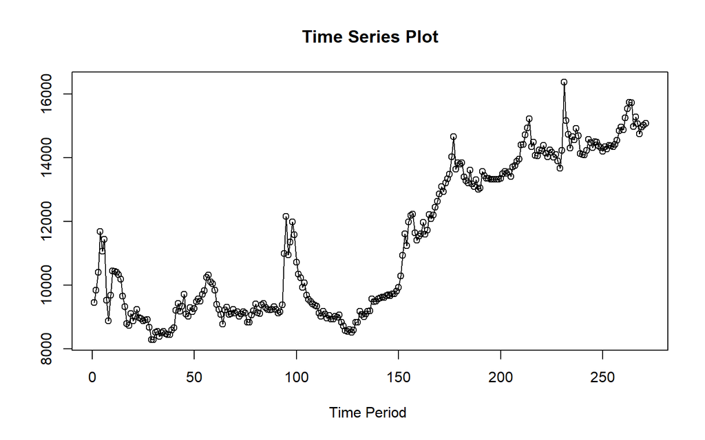

```r
library(ggplot2)
plot_ts <- ts.plot(ts, xlab="Time Period ", ylab="",
        main = "Time Series Plot")
points(ts)
```

Plot deret waktu di atas menunjukkan bahwa data cenderung membuat grafik tren, dan tidak stasioner dalam rataan maupun ragamnya .

### Plot ACF

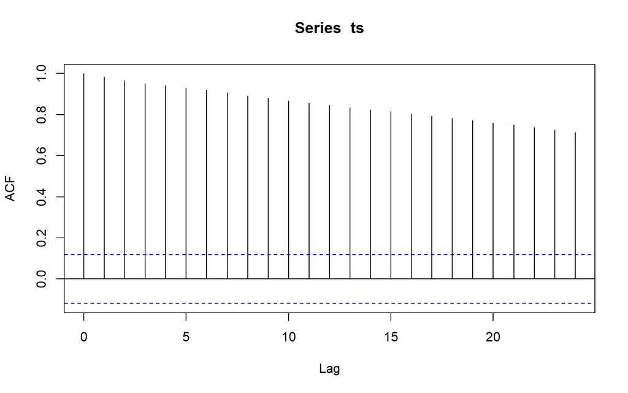

```r
acf(ts)
```

Berdasarkan plot ACF, terlihat bahwa plot ACF pada data tersebut cenderung *tails off* slowly yang artinya mengindikasikan tidak stasioner dalam rataannya.

### Uji ADF

```r
library(tseries)
adf.test(ts)
```

```
##
##  Augmented Dickey-Fuller Test
##
## data:  ts
## Dickey-Fuller = -2.5829, Lag order = 6, p-value = 0.3305
## alternative hypothesis: stationary
```

$H_0$ : Data tidak stasioner dalam rataan

$H_1$ : Data stasioner dalam rataan

Berdasarkan uji ADF tersebut, didapat *p-value* sebesar 0.3305 yang lebih besar dari taraf nyata 5% sehingga tak tolak $H_0$ dan menandakan bahwa data tidak stasioner dalam rataan . Hal ini sesuai dengan hasil eksplorasi data. .

### Plot Box-Cox

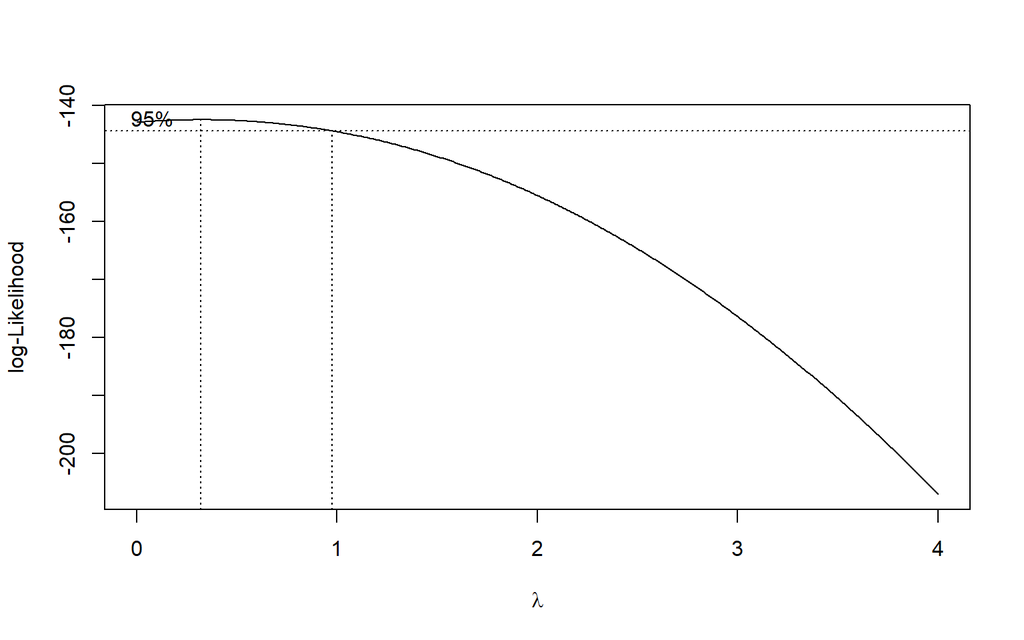

```r
index <- seq(1:271)
bc = boxcox(ts~index, lambda = seq(0,4,by=0.01))
```

```r
#Nilai Rounded Lambda
lambda <- bc$x[which.max(bc$y)]
lambda
```

```
## [1] 0.32
```

```r
#SK
bc$x[bc$y > max(bc$y) - 1/2 * qchisq(.95,1)]
```

```
##  [1] 0.00 0.01 0.02 0.03 0.04 0.05 0.06 0.07 0.08 0.09 0.10 0.11 0.12 0.13 0.14
## [16] 0.15 0.16 0.17 0.18 0.19 0.20 0.21 0.22 0.23 0.24 0.25 0.26 0.27 0.28 0.29
## [31] 0.30 0.31 0.32 0.33 0.34 0.35 0.36 0.37 0.38 0.39 0.40 0.41 0.42 0.43 0.44
## [46] 0.45 0.46 0.47 0.48 0.49 0.50 0.51 0.52 0.53 0.54 0.55 0.56 0.57 0.58 0.59
## [61] 0.60 0.61 0.62 0.63 0.64 0.65 0.66 0.67 0.68 0.69 0.70 0.71 0.72 0.73 0.74
## [76] 0.75 0.76 0.77 0.78 0.79 0.80 0.81 0.82 0.83 0.84 0.85 0.86 0.87 0.88 0.89
## [91] 0.90 0.91 0.92 0.93 0.94 0.95 0.96 0.97
```

## Kestasioneran Partisi Data

Pada tahap ini akan dilakukan pengecekan kestasioneran data seabnyak 2 kali terhadap 2 partisi/bagian data yang pemilihannya subjektif dari keinginan peneliti dengan mengacu pemotongan dilakukan tidak ketiika hendak naik atau turunnya nilai data time series

### Partisi pertama

partisi pertama ini ingin dilihat ketika data seakan sebelum naik di plot data seluruhnya yakni dari amatan 1 hingga ke 120.

```r
partisits1 <- ts[1:120] |> ts()
mean(partisits1)
```

```
## [1] 9436.875
```

```r
var(partisits1)
```

```
## [1] 597247
```

#### Plot Time Series

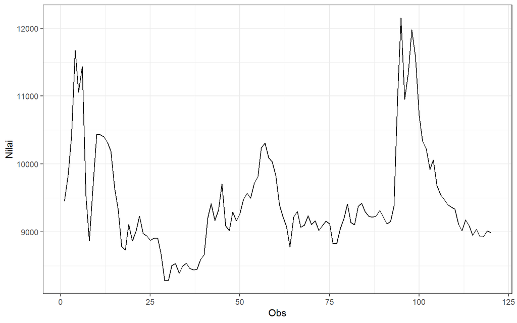

```r
partisits1 |> as_tsibble() |>
  ggplot(aes(x = index, y = value)) +
  geom_line() + theme_bw() +
  xlab("Obs") + ylab("Nilai")
```

Plot deret waktu di atas menunjukkan bahwa cenderus tidak stasioner dalam rataan, ditandai dengan data yang tidak menyebar di sekitar nilai tengahnya dandata terlihat tidak stasioner dalam ragam, hal ini ditandai dengan lebar pita yang cenderung berbeda pula.

#### Plot ACF

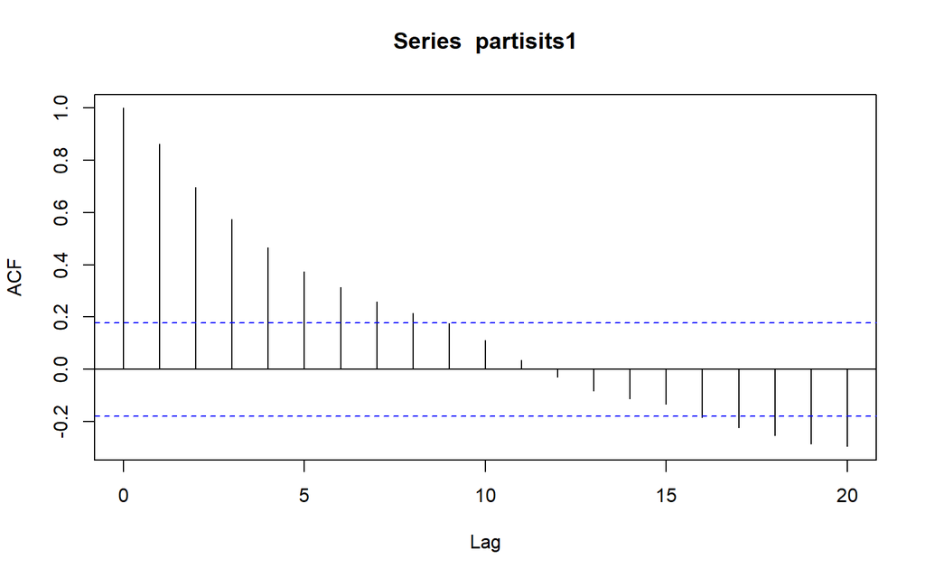

```r
acf(partisits1)
```

Berdasarkan plot ACF, terlihat bahwa plot ACF pada data tersebut cenderung *tails off* slowly dan membentuk sinus yang artinya data tidak stastioner dalam rataan.

#### Uji ADF

```r
adf.test(partisits1)
```

```
##
##  Augmented Dickey-Fuller Test
##
## data:  partisits1
## Dickey-Fuller = -3.1386, Lag order = 4, p-value = 0.1037
## alternative hypothesis: stationary
```

$H_0$ : Data tidak stasioner dalam rataan

$H_1$ : Data stasioner dalam rataan

Berdasarkan uji ADF tersebut, didapat *p-value* sebesar 0.1037 yang lebih besar dari taraf nyata 5% sehingga tak tolak $H_0$ dan menandakan bahwa data tidak stasioner dalam rataan. Hal ini sesuai dengan hasil eksplorasi menggunakan plot time series dan plot ACF.

#### Plot Boxcox

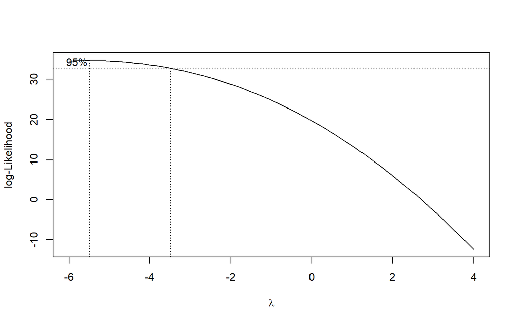

```r
index1 <- seq(1:120)
bc1 = boxcox(partisits1~index1, lambda = seq(-6,4,by=1))
```

```r
#Nilai Rounded Lambda
lambda1 <- bc1$x[which.max(bc1$y)]
lambda1
```

```
## [1] -5.494949
```

```r
#SK
bc1$x[bc1$y > max(bc1$y) - 1/2 * qchisq(.95,1)]
```

```
##  [1] -6.000000 -5.898990 -5.797980 -5.696970 -5.595960 -5.494949 -5.393939
##  [8] -5.292929 -5.191919 -5.090909 -4.989899 -4.888889 -4.787879 -4.686869
## [15] -4.585859 -4.484848 -4.383838 -4.282828 -4.181818 -4.080808 -3.979798
## [22] -3.878788 -3.777778 -3.676768 -3.575758
```

### Partisi kedua

partisi kedua ini ingin dilihat ketika data seakan naik di plot data seluruhnya yakni dari amatan 126 hingga ke 175 sebanyak 50 amatan.

```r
partisits2 <- ts[126:175] |> ts()
mean(partisits2)
```

```
## [1] 10710.02
```

```r
var(partisits2)
```

```
## [1] 2342629
```

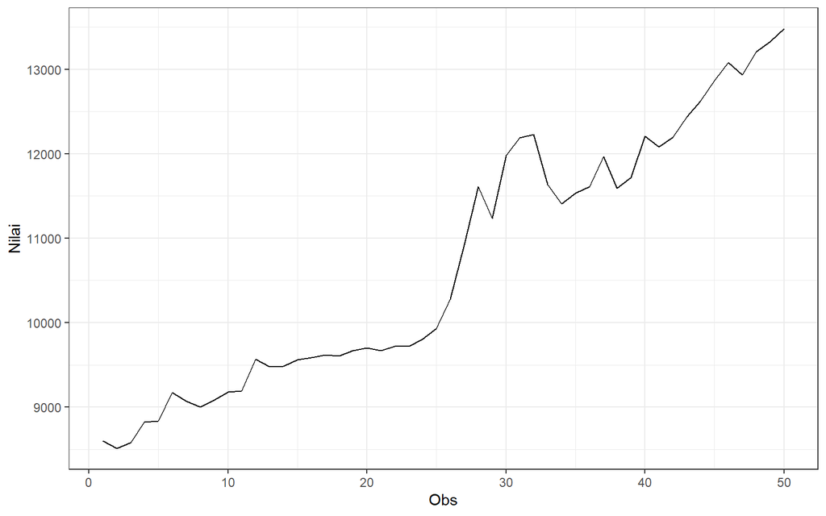

```r
#### Plot Time Series
partisits2 |> as_tsibble() |>
  ggplot(aes(x = index, y = value)) +
  geom_line() + theme_bw() +
  xlab("Obs") + ylab("Nilai")
```

Plot deret waktu di atas menunjukkan bahwa data cenderung trend dan tidak stasioner dalam rataan, semntara untuk stasioner dalam ragamnya juga terlihat tidak terpenuhi.

#### Plot ACF

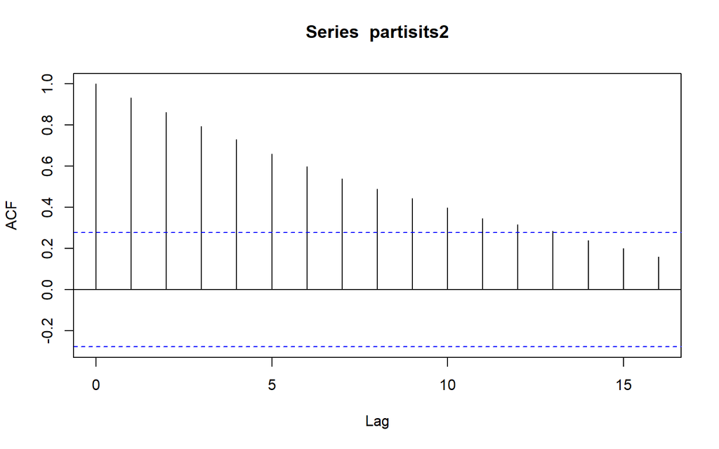

```r
acf(partisits2)
```

Berdasarkan plot ACF, terlihat bahwa plot ACF pada data tersebut cenderung tails off. Berarti, belum stasioner.

#### Uji ADF

```r
adf.test(partisits2)
```

```
##
##  Augmented Dickey-Fuller Test
##
## data:  partisits2
## Dickey-Fuller = -2.5886, Lag order = 3, p-value = 0.3382
## alternative hypothesis: stationary
```

$H_0$ : Data tidak stasioner dalam rataan

$H_1$ : Data stasioner dalam rataan

Berdasarkan uji ADF tersebut, didapat *p-value* sebesar 0.338 yang lebih besar dari taraf nyata 5% sehingga tak tolak $H_0$ dan menandakan bahwa data tidak stasioner dalam rataan. Hal ini sesuai dengan hasil eksplorasi menggunakan plot time series dan plot ACF.

#### Plot Boxcox

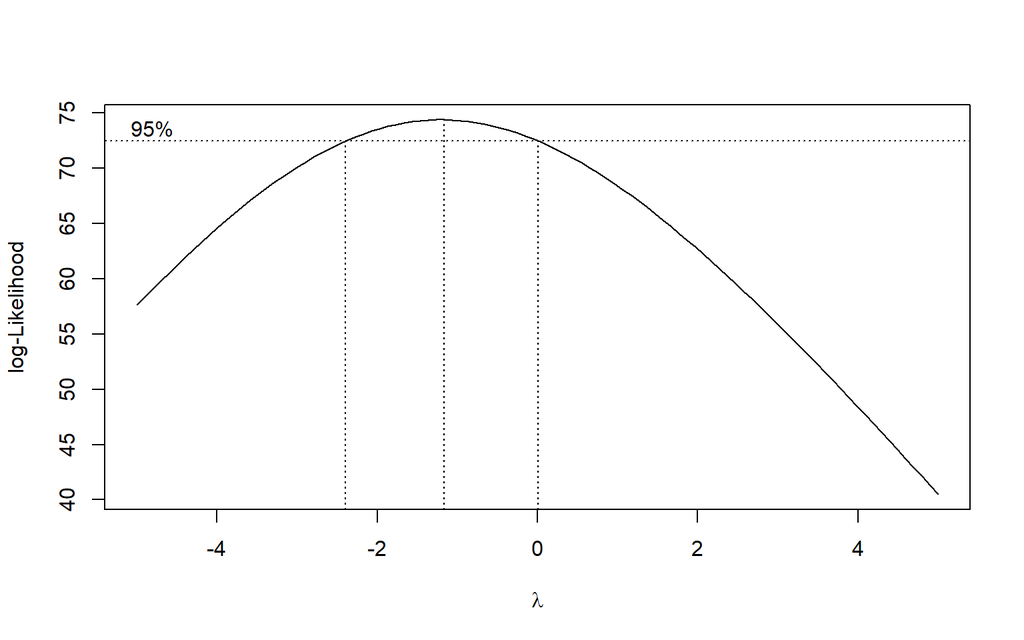

```r
index2 <- seq(1:50)
bc2 = boxcox(partisits2~index2, lambda = seq(-5,5,by=1))
```

```r
#Nilai Rounded Lambda
lambda2 <- bc2$x[which.max(bc2$y)]
lambda2
```

```
## [1] -1.161616
```

```r
#SK
bc2$x[bc2$y > max(bc2$y) - 1/2 * qchisq(.95,1)]
```

```
##  [1] -2.37373737 -2.27272727 -2.17171717 -2.07070707 -1.96969697 -1.86868687
##  [7] -1.76767677 -1.66666667 -1.56565657 -1.46464646 -1.36363636 -1.26262626
## [13] -1.16161616 -1.06060606 -0.95959596 -0.85858586 -0.75757576 -0.65656566
## [19] -0.55555556 -0.45454545 -0.35353535 -0.25252525 -0.15151515 -0.05050505
```

Gambar di atas menunjukkan nilai *rounded value* ($\lambda$) optimum sebesar **-1.16** dan pada selang kepercayaan 95% nilai memiliki batas bawah **-2.37** dan batas atas **-0.05**. Selang tersebut tudak memuat nilai satu sehingga dapat dikatakan bahwa data tidak stasioner dalam ragam.

### Partisi ketiga

partisi ketiga ini adalah partisi tambahan dimana peneliti ingin melihat ketika data setelah naik di plot data seluruhnya yakni dari amatan 211 hingga ke 260 sebanyak 50 amatan.

```r
partisits3 <- ts[211:260] |> ts()
mean(partisits3)
```

```
## [1] 14441.06
```

```r
var(partisits3)
```

```
## [1] 179617.6
```

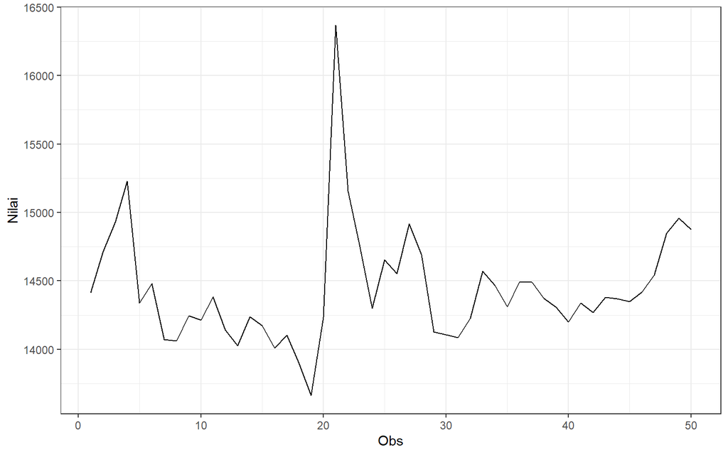

```r
#### Plot Time Series
partisits3 |> as_tsibble() |>
  ggplot(aes(x = index, y = value)) +
  geom_line() + theme_bw() +
  xlab("Obs") + ylab("Nilai")
```

Plot deret waktu di atas menunjukkan bahwa data cenderung seakan stasioner dalam rataan, semntara untuk stasioner dalam ragamnya juga terlihat tidak terpenuhi.

#### Plot ACF

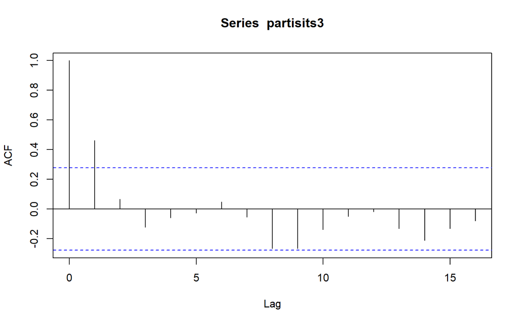

```r
acf(partisits3)
```

Berdasarkan plot ACF, terlihat bahwa plot ACF pada data tersebut cut off pada lag pertama. Berarti ada indikasi data stasioner dalam rataan.

#### Uji ADF

```r
adf.test(partisits3)
```

```
##
##  Augmented Dickey-Fuller Test
##
## data:  partisits3
## Dickey-Fuller = -3.2775, Lag order = 3, p-value = 0.08521
## alternative hypothesis: stationary
```

$H_0$ : Data tidak stasioner dalam rataan

$H_1$ : Data stasioner dalam rataan

#### Plot Boxcox

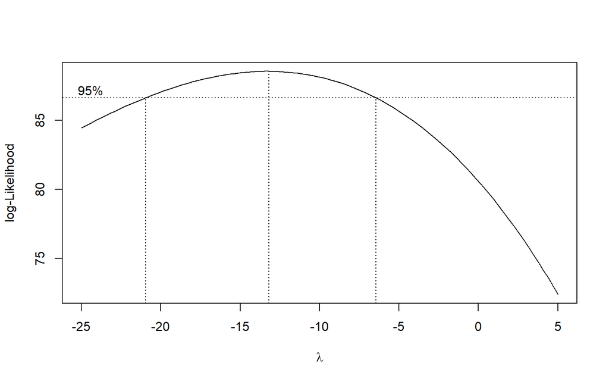

```r
index3 <- seq(1:50)
bc3 = boxcox(partisits3~index3, lambda = seq(-25,5,by=10))
```

```r
#Nilai Rounded Lambda
lambda3 <- bc3$x[which.max(bc3$y)]
lambda3
```

```
## [1] -13.18182
```

```r
#SK
bc3$x[bc3$y > max(bc3$y) - 1/2 * qchisq(.95,1)]
```

```
##  [1] -20.757576 -20.454545 -20.151515 -19.848485 -19.545455 -19.242424
##  [7] -18.939394 -18.636364 -18.333333 -18.030303 -17.727273 -17.424242
## [13] -17.121212 -16.818182 -16.515152 -16.212121 -15.909091 -15.606061
## [19] -15.303030 -15.000000 -14.696970 -14.393939 -14.090909 -13.787879
## [25] -13.484848 -13.181818 -12.878788 -12.575758 -12.272727 -11.969697
## [31] -11.666667 -11.363636 -11.060606 -10.757576 -10.454545 -10.151515
## [37]  -9.848485  -9.545455  -9.242424  -8.939394  -8.636364  -8.333333
## [43]  -8.030303  -7.727273  -7.424242  -7.121212  -6.818182  -6.515152
```